# Proyecto Avance 1-Simulacion

```r
library(readxl)
library(tidyverse)
```

Proyecto Grupal N°1 (P1)

Principales Estrategias 2025-2035:

• Incrementar la participación del mercado en un 40% • Incrementar la utilidad después de impuestos en un 45% • Ser reconocidos como una empresa innovadora en el sector

SE PROPONEN 2 SOLUCIONES FACTIBLES PARA LAS ALTAS MERMAS QUE ASCIENDEN AL 8% DEL COSTO PROD.+OTROS

CASO 1.

1.- Sistema de Tapado Automático de Mermelada:

```r
DF1 <- read_excel("DatosEPR1 2024-1.xlsx",sheet = "Data Sistema Tapado")
```

```r
#Costos.
maquina<-500000 #costo de la maquina
instalacionV<-gen_unif(80000,85000) #Servicio de instalacion y validacion(incluye capacitacion)
```

```
Error in gen_unif(80000, 85000) :
  argument "b" is missing, with no default
```

```r
Mantenimiento<-rnorm(1,7515.0150,378.3456)+rnorm(1,7588.8322,381.5869)+
  rnorm(1,7435.5782,332.3644)+rnorm(1,7413.813  ,387.360)
```

```r
completo<-function(a){
  m<-a[complete.cases(a)]
  return(m)
}
```

```r
Venta_maquina<-sample(x = c(rnorm(1,127716.44   ,20785.23   ),runif(1,123081.7,214295.6),rnorm(1,203886.33  ,20695.67)),size = 1,prob = c(0.35,0.4,0.25))
Venta_maquina
```

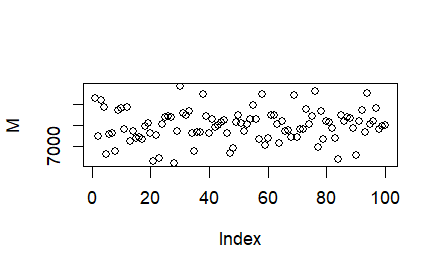

```r
plot(M)
```

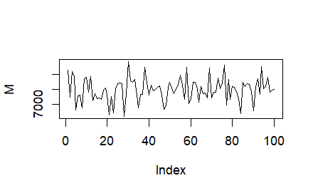

```r
plot(M,type = "l")
```

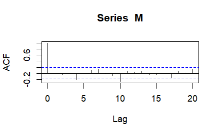

```r
acf(M)
```

CASO 2.

2.- Tapado Manual con aplicación de elementos poka-yoke:

OPERACION MANUAL->COMPRAR 2 ELEMENTOS

EN CADA CAMBIO SE COMPRA UN ELEMENTO SIN ALTERAR EL COSTO. EL COSTO DE ESTE ELEMENTO DEBE CAMBIAR CADA 6 MESES -> VIENE DE ALEMANIA. VARIACION DEL COSTO DE TRANSPORTE INTERNACIONAL-> DATA HISTORICA DE INCOTERM DDP(DELIVERED DUTY PAID) PROVISTA POR EL PROVEEDOR.

```r
DF2<- read_excel("DatosEPR1 2024-1.xlsx",
    sheet = "Data Elemento Poka-Yoke")
```

```r
Transporte<-completo(DF2$Precio_transporte)
COperarioB<-completo(DF2$`Con Bono`)
COperarioSB<-completo(DF2$`Sin Bono`)
Seguro<-completo(DF2$`Costo Reproceso`)
```

COSTO DE TRANSPORTE DEL CAMBIO

```r
hist(Transporte)
boxplot(Transporte)
```

[output not shown]

```r
plot(Transporte)
plot(Transporte,type = "l")
acf(Transporte)
```

[output not shown]

```
summary statistics
------
min:  6640.469   max:  8198.609
median:  7576.893
mean:  7515.015
estimated sd:  386.1473
estimated skewness:  -0.4382806
estimated kurtosis:  3.014231
```

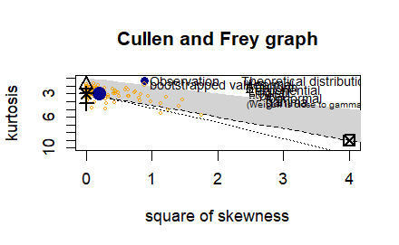

```r
descdist(M_1,boot = 100)
```

```
summary statistics
------
min:  6779.099   max:  8417.203
median:  7475.524
mean:  7588.832
estimated sd:  389.4555
estimated skewness:  0.5311209
estimated kurtosis:  3.149325
```

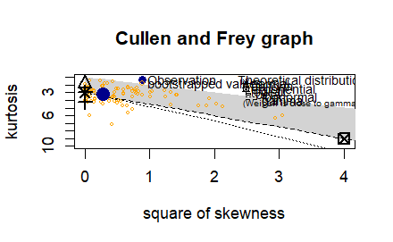

```r
descdist(M_2,boot = 100)
```

```
summary statistics
------
min:  6718.362   max:  8091.328
median:  7491.723
mean:  7435.578
estimated sd:  339.2179
estimated skewness:  -0.3610892
estimated kurtosis:  2.935114
```

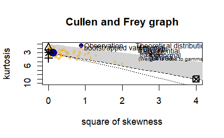

```r
descdist(M_3,boot = 100)
```

```
summary statistics
------
min:  6591.547   max:  8292.493
median:  7405.667
mean:  7413.813
estimated sd:  395.3476
estimated skewness:  -0.08824264
estimated kurtosis:  3.185151
```

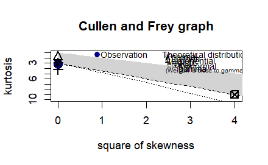

```r
descdist(M_4)
```

Posiblemente se trate de una normal

```r
fitdist(Transporte,"norm")
```

[output not shown]

```r
GB_T<-gofstat(fitdist(M_1,"norm"))
GB_T$chisqpvalue
GB_T$kstest
ks.test(Transporte,pnorm,20231.456      ,2467.986   )
```

[output not shown]

```r
plot(fitdist(M_1,"norm"))
```

[output not shown]

```r
Transporte<-rnorm(1,20231.456       ,2467.986)
```

AL DESGASTARSE NO PUEDE TOMAR SU FORMA ORIGINAL NO REQUIERE COSTOS DE CAPACITACION POR QUE LA OP NO ES COMPLICADA.

COSTO PROMEDIO DE 1 OPERARIO:

BONO DE PRODUCTIVIDAD -> 70% DE ALCANZARSE, EXISTE DATA HISTORICA BASA DE EN ACTIVIDAD SIMILAR EN LA EMPRESA (INCLUYE HORAS EXTRAS DEPENDIENDO DEL MES)

SE REQUIEREN POR LO MENOS 3 PERSONAS (1 POR TURNO)

ADICIONALMENTE SEGURO DE 200 MENSUALES POR LESIONES X TRABAJADOR

INVERTIR EN COSTO DE REPROCESO PORQUE ESTUDIOS DE GAGE R&R INDICAN ERROR ENTRE OPERARIOS. PARA ESTIMAR SE CUENTA CON DATA HISTORICA DE FRUCTUS

Considerando la información presentada evaluación de proyectos de 5 años un Costo Ponderado de Capital del 15% anual se le pide definir cuál de los 2 proyectos debe ser implementado SOLO SE PUEDE FINANCIAR UNO

BENEFICIOS:

Para el cálculo de beneficios relevantes operativos considere la información de costos de producción proyectados:

PRIMER AÑO ~  
gen_triangular( 3,699,850 3,027,150 3,223,487 ) SEGUNDO AÑO ~ gen_triangular( 4,178,405 3,418,695 3,836,359 ) TERCER AÑO ~ gen_triangular(4,641,771 3,797,812 3,836,359 ) 4TO AÑO ~ gen_triangular( 5,196,441 4,251,633 4,673,299 ) 5TO AÑO ~ gen_triangular(5,570,937 4,558,040 5,039,321 )

Para ello, realice un resumen ejecutivo tomando en cuenta los siguientes puntos:

BENEFICIOS GENERALES.

```r
Auno<-gen_triangular(1,3699850,3027150,3223487)
Ados<-gen_triangular(1,4178405,3418695,3836359)
Atres<-gen_triangular(1,4641771,3797812,3836359)
Acuatro<-gen_triangular(1,5196441,4251633,4673299)
Acinco<-gen_triangular(1,5570937,4558040,5039321)
```

1. Describa cuál es la métrica a evaluar para la toma de decisiones y cuáles son sus componentes por cada proyecto?. (3 puntos)
2. Infiera todas las distribuciones de probabilidad asociadas a la data histórica existente (5 puntos)
3. Defina cuál será el procedimiento lógico a seguir para responder cuál es el proyecto más adecuado a implementar en FRUCTUS (2 puntos)
4. Considerando un número de réplicas que permita obtener un medio ancho de intervalo de confianza igual al 5% de la media, realice el intervalo de confianza de la métrica propuesta y la probabilidad de que cada uno de los proyectos sea aprobado (7 puntos)
5. Indique cuál debe ser implementado?, Por qué?. Tome como base los resultados obtenidos en d) (2 puntos)